```python
import pandas as pd
import numpy as np
import matplotlib.pyplot as plt
from matplotlib import pyplot
import seaborn as sns
from sklearn.impute import SimpleImputer,KNNImputer
from sklearn.model_selection import train_test_split
from sklearn.ensemble import RandomForestRegressor
from sklearn.model_selection import cross_val_score, cross_validate
from sklearn.model_selection import GridSearchCV

# machine learning
from sklearn.linear_model import LogisticRegression
from sklearn.ensemble import RandomForestClassifier
from sklearn.neighbors import KNeighborsClassifier
from sklearn.tree import DecisionTreeClassifier
from sklearn.preprocessing import OneHotEncoder
from sklearn.metrics import accuracy_score, confusion_matrix
from sklearn.metrics import roc_curve, roc_auc_score, auc
from scipy import stats
import matplotlib.pyplot as plt
import sklearn.metrics as metrics
# import xgboost as xgb
```

```python
# random forest for feature importance on a regression problem
from sklearn.datasets import make_regression
from sklearn.ensemble import RandomForestRegressor
from matplotlib import pyplot
```

# Phân tích hành vi khách hàng

```python
df = pd.read_excel('C:/Users/Admin/Downloads/train.xlsx')
```

```python
df1 = df.copy()
```

```python
df.shape
```

```
(32561, 12)
```

```python
df.info()
```

```
<class 'pandas.core.frame.DataFrame'>
RangeIndex: 32561 entries, 0 to 32560
Data columns (total 12 columns):
 #   Column           Non-Null Count  Dtype
---  ------           --------------  -----
 0   id               32561 non-null  int64
 1   age              32561 non-null  int64
 2   sector           32561 non-null  object
 3   edu              32561 non-null  object
 4   marital_status   32561 non-null  object
 5   field            32561 non-null  object
 6   family_rel       32561 non-null  object
 7   gender           32561 non-null  object
 8   investment_gain  32561 non-null  int64
 9   investment_loss  32561 non-null  int64
 10  working_hours    32561 non-null  int64
 11  high_income      32561 non-null  object
dtypes: int64(5), object(7)
memory usage: 3.0+ MB
```

```python
df.describe()
```

|  | id | age | investment_gain | investment_loss | working_hours |
| --- | --- | --- | --- | --- | --- |
| count | 32561.000000 | 32561.000000 | 32561.000000 | 32561.000000 | 32561.000000 |
| mean | 16281.000000 | 38.581647 | 1077.648844 | 87.303830 | 40.437456 |
| std | 9399.695394 | 13.640433 | 7385.292085 | 402.960219 | 12.347429 |
| min | 1.000000 | 17.000000 | 0.000000 | 0.000000 | 1.000000 |
| 25% | 8141.000000 | 28.000000 | 0.000000 | 0.000000 | 40.000000 |
| 50% | 16281.000000 | 37.000000 | 0.000000 | 0.000000 | 40.000000 |
| 75% | 24421.000000 | 48.000000 | 0.000000 | 0.000000 | 45.000000 |
| max | 32561.000000 | 90.000000 | 99999.000000 | 4356.000000 | 99.000000 |

Trong các biến liên tục ,2 biến investment gain có phân bố rời rạc nhất với std cao

```python
cat_cols = df.select_dtypes('object').columns
num_cols = df.select_dtypes(['int64','float64']).columns
```

```python
print('total {} categories: {}'.format(len(cat_cols), cat_cols))
print('total {} numeric: {} '.format(len(num_cols), num_cols))
```

```
total 7 categories: Index(['sector', 'edu', 'marital_status', 'field', 'family_rel', 'gender',
       'high_income'],
      dtype='object')
total 5 numeric: Index(['id', 'age', 'investment_gain', 'investment_loss', 'working_hours'], dtype='object')
```

```python
#missing value
missing_data = pd.DataFrame({"Missing value": df.isnull().sum()/ len(df.index)*100})
missing_data.reset_index()
```

|  | index | Missing value |
| --- | --- | --- |
| 0 | id | 0.0 |
| 1 | age | 0.0 |
| 2 | sector | 0.0 |
| 3 | edu | 0.0 |
| 4 | marital_status | 0.0 |
| 5 | field | 0.0 |
| 6 | family_rel | 0.0 |
| 7 | gender | 0.0 |
| 8 | investment_gain | 0.0 |
| 9 | investment_loss | 0.0 |
| 10 | working_hours | 0.0 |
| 11 | high_income | 0.0 |

```python
def find_outliers_IQR(df):

   q1=df.quantile(0.25)

   q3=df.quantile(0.75)

   IQR=q3-q1

   outliers = df[((df<(q1-1.5*IQR)) | (df>(q3+1.5*IQR)))]

   return outliers
```

```python
OL = find_outliers_IQR(df)
```

```python
outlier_data = pd.DataFrame({"Outlier % count": 100 - (OL.isnull().sum()/ len(df.index)*100)})
outlier_data = outlier_data.reset_index()
outlier_data
```

|  | index | Outlier % count |
| --- | --- | --- |
| 0 | id | 0.000000 |
| 1 | age | 0.439176 |
| 2 | sector | 0.000000 |
| 3 | edu | 0.000000 |
| 4 | marital_status | 0.000000 |
| 5 | field | 0.000000 |
| 6 | family_rel | 0.000000 |
| 7 | gender | 0.000000 |
| 8 | investment_gain | 8.328983 |
| 9 | investment_loss | 4.665090 |
| 10 | working_hours | 27.664998 |
| 11 | high_income | 0.000000 |

tập dữ liệu không có missing value, các biến investment gain, loss, working hour có % outlier cao , outlier được xác định phương pháp IQR, tuy nhiên bài trình bày này sẽ không xử lý outlier vì woe có ưu điểm là gán woe cho các khoảng outlier và thuật toán tree-based như random-forest không nhạy cảm với dữ liệu ngoại lai

```python
from collections import Counter
```

```python
# summarize the class distribution
target = df.values[:,-1]
counter = Counter(target)
for k,v in counter.items():
    per = v / len(target) * 100
    print('Class=%s, Count=%d, Percentage=%.3f%%' % (k, v, per))
```

```
Class=no, Count=24720, Percentage=75.919%
Class=yes, Count=7841, Percentage=24.081%
```

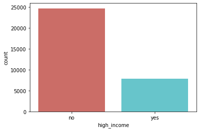

```python
sns.countplot(x = 'high_income', data = df, palette ='hls')
plt.show()
```

có 7841 khách hàng có high income chiếm 24% tập dữ liệu, 24720 khách hàng low income chiếm 75% tập dữ liệu

```python
df_low = df.loc[(df['high_income'] != 'no')]
```

```python
df_high = df.loc[(df['high_income'] != 'high')]
```

```
number of numeric field:  4
```

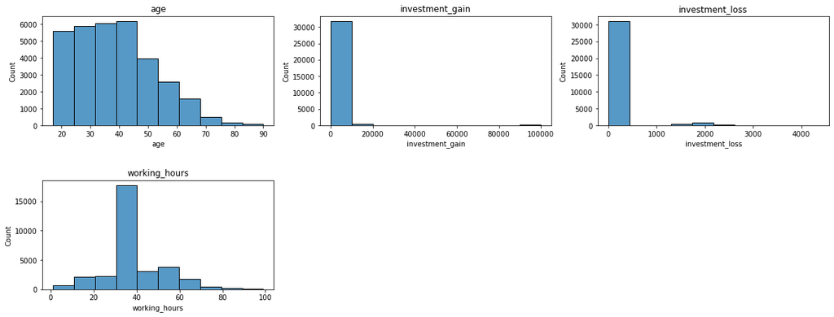

```python
#histogram
numeric_cols = ['age', 'investment_gain', 'investment_loss', 'working_hours']

def _plot_numeric_classes(col, bins=10):
    sns.histplot(df_high[col],
                 bins = bins)

def _distribution_numeric(numeric_cols, row=3, col=3, figsize=(20, 15), bins = 10):

    print('number of numeric field: ', len(numeric_cols))
    plt.figure(figsize = figsize)
    plt.subplots_adjust(left=None, bottom=None, right=None, top=None, wspace=0.2, hspace=0.5)
    for i in range(1, len(numeric_cols)+1, 1):
      try:
        plt.subplot(row, col, i)
        _plot_numeric_classes(numeric_cols[i-1], bins = bins)
        plt.title(numeric_cols[i-1])
      except:
        break

_distribution_numeric(numeric_cols, row=5, col=3, figsize=(20, 20), bins = 10)
```

```
number of category field:  6
```

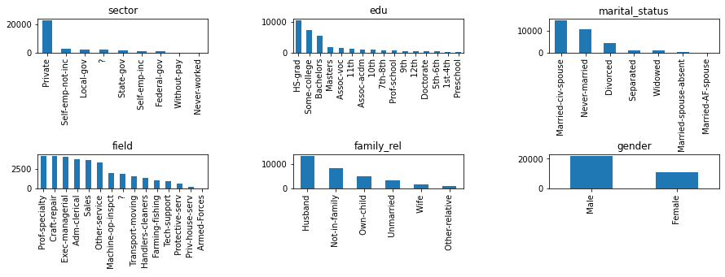

```python
#Đối với biến phân loại
cate_cols = ('sector', 'edu', 'marital_status', 'field', 'family_rel', 'gender')

def _plot_bar_classes(cate_cols):
  df_high[cate_cols].value_counts().plot.bar(figsize=(15,10))

def _distribution_cate(cate_cols, row , col , figsize = (20, 15)):

  print('number of category field: ', len(cate_cols))

  plt.figure(figsize = figsize)
  plt.subplots_adjust(left=None, bottom=None, right=None, top=None, wspace=0.5, hspace=3)
  for i in range(1, len(cate_cols)+1, 1):
    try:
      plt.subplot(row, col, i)
      _plot_bar_classes(cate_cols[i-1])
      plt.title(cate_cols[i-1])
    except:
      break

_distribution_cate(cate_cols, row = 4, col = 3, figsize = (20, 20))
```

```python
def _plot_numeric_classes(col, bins=10):
    sns.histplot(df_low[col],
                 bins = bins)
```

```
number of numeric field:  4
```

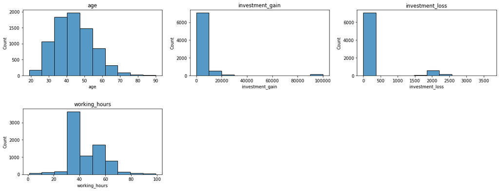

```python
_distribution_numeric(numeric_cols, row=5, col=3, figsize=(20, 20), bins = 10)
```

```python
def _plot_bar_classes(cate_cols):
  df_low[cate_cols].value_counts().plot.bar(figsize=(15,10))
```

```
number of category field:  6
```

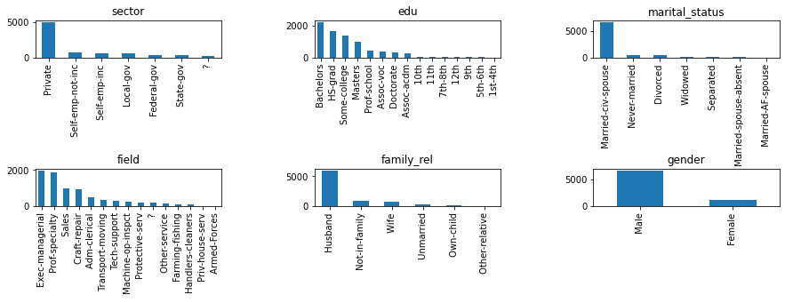

```python
def _distribution_cate(cate_cols, row , col , figsize = (20, 15)):

  print('number of category field: ', len(cate_cols))

  plt.figure(figsize = figsize)
  plt.subplots_adjust(left=None, bottom=None, right=None, top=None, wspace=0.5, hspace=3)
  for i in range(1, len(cate_cols)+1, 1):
    try:
      plt.subplot(row, col, i)
      _plot_bar_classes(cate_cols[i-1])
      plt.title(cate_cols[i-1])
    except:
      break

_distribution_cate(cate_cols, row = 4, col = 3, figsize = (20, 20))
```

```
number of numeric field:  4
```

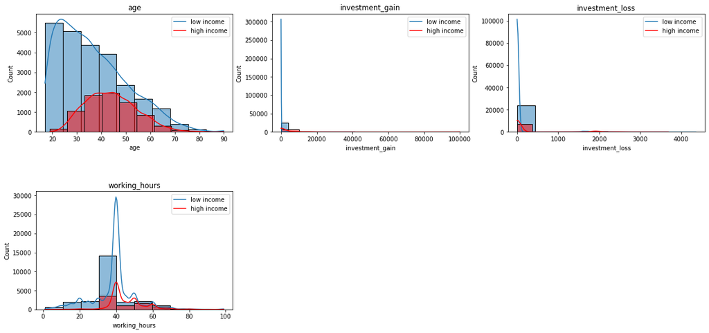

```python
#quan hệ giữa Biến liên tục vs biến mục tiêu high income

def _plot_numeric_classes(col, bins=20, kde=True):
    sns.histplot(df[col][df['high_income'] == 'no'],
                 bins = bins,
                 kde = kde)
    sns.histplot(df[col][df['high_income'] == 'yes'],
                 bins = bins,
                 kde = kde,color='red')
    plt.legend(['low income', 'high income'])

def _distribution_numeric(numeric_cols, row=3, col=3, figsize=(20, 15), bins = 10):

    print('number of numeric field: ', len(numeric_cols))

    plt.figure(figsize = figsize)
    plt.subplots_adjust(left=None, bottom=None, right=None, top=None, wspace=0.2, hspace=0.5)
    for i in range(1, len(numeric_cols)+1, 1):
      try:
        plt.subplot(row, col, i)
        _plot_numeric_classes(numeric_cols[i-1], bins = bins)
        plt.title(numeric_cols[i-1])
      except:
        break

_distribution_numeric(numeric_cols, row=4, col=3, figsize=(20, 20), bins = 10)
```

```python
df.groupby('high_income').mean()
```

| high_income | id | age | investment_gain | investment_loss | working_hours |
| --- | --- | --- | --- | --- | --- |
| no | 16252.393770 | 36.783738 | 148.752468 | 53.142921 | 38.840210 |
| yes | 16371.185691 | 44.249841 | 4006.142456 | 195.001530 | 45.473026 |

chi tiết vào từng biến phân loại 'sector', 'edu', 'marital_status', 'field', 'family_rel', 'gender', từng biến sẽ được vẽ trong chart tương ứng

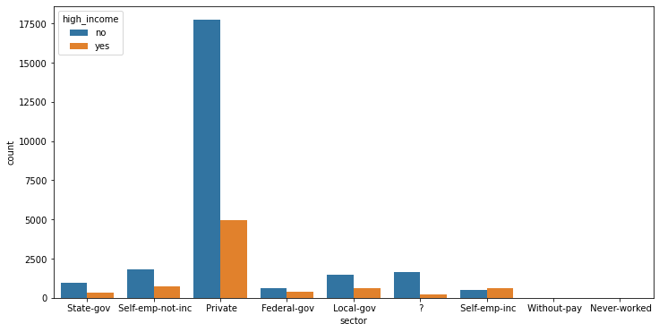

```python
#creating a countplot to see the counts of purpose of loans by not.fully.paid
plt.figure(figsize=(12,6))
sns.countplot(data=df, x='sector', hue='high_income')
```

```python
channel = df[["id","sector", "high_income"]]
channel = channel.groupby([channel["sector"],
channel["high_income"]])["id"].count().unstack(level=1).fillna(0)
channel.reset_index()['no']
```

[output not shown]

```python
channel_total = channel['no']+channel['yes']
channel_percentage = channel['yes']/(channel_total)*100
pd.DataFrame({"high income percentage": channel_percentage,
"Total customer": channel_total }).sort_values(by="high income percentage",ascending=False).head(10)
```

| sector | high income percentage | Total customer |
| --- | --- | --- |
| Self-emp-inc | 55.734767 | 1116.0 |
| Federal-gov | 38.645833 | 960.0 |
| Local-gov | 29.479216 | 2093.0 |
| Self-emp-not-inc | 28.492719 | 2541.0 |
| State-gov | 27.195686 | 1298.0 |
| Private | 21.867289 | 22696.0 |
| ? | 10.403050 | 1836.0 |
| Never-worked | 0.000000 | 7.0 |
| Without-pay | 0.000000 | 14.0 |

khác biệt chính về sector là khách hàng self-emp-inc sẽ chủ yếu là kh có thu nhập cao, cụ thể là 56% khách hàng thuộc sector này sẽ có high income

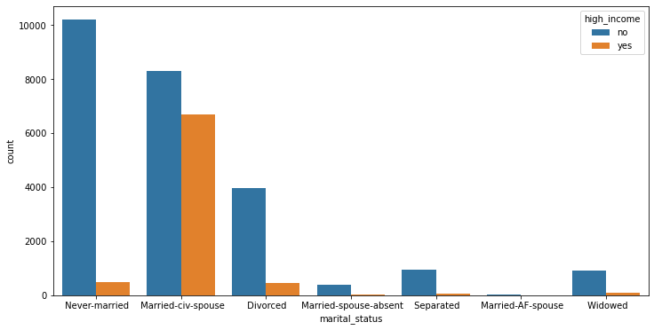

```python
#creating a countplot to see the counts of purpose of loans by not.fully.paid
plt.figure(figsize=(12,6))
sns.countplot(data=df, x='marital_status', hue='high_income')
```

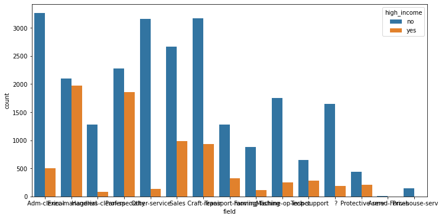

```python
plt.figure(figsize=(12,6))
sns.countplot(data=df, x='field', hue='high_income')
```

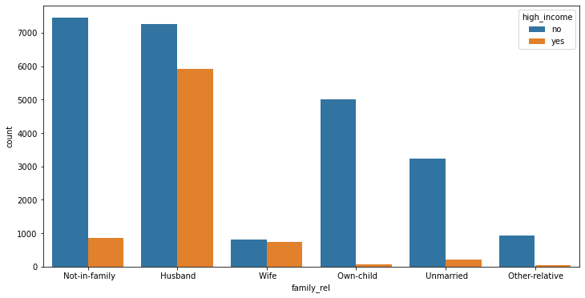

```python
plt.figure(figsize=(12,6))
sns.countplot(data=df, x='family_rel', hue='high_income')
```

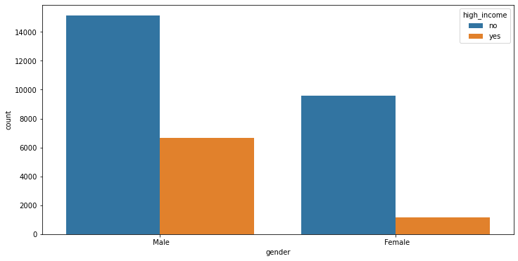

```python
plt.figure(figsize=(12,6))
sns.countplot(data=df, x='gender', hue='high_income')
```

# Xây dựng mô hình dự báo sử dụng logistic regression và random forest

# Phân tích đơn biến - woe iv calculation

```python
#Woe được sử dụng như 1 cách biến đổi (transform) biến , iv được dùng để chọn các biến có khả năng phân biệt
```

```python
df['high_income'] = np.where(df['high_income'] == 'no', 0, 1)
```

```python
def bin_table(data, col_name, n_bins=10):
    df1 = df.loc[:, [col_name, 'high_income']]
    if df1[col_name].dtypes != 'object':
        bins, threshold = pd.qcut(df1[col_name], q=n_bins, retbins=True, duplicates='drop')
        threshold[0] = -np.inf
        threshold[-1] = np.inf
        bins, threshold = pd.cut(df1[col_name], bins=threshold, retbins=True)
        df1[col_name] = bins
    elif df1[col_name].dtypes == 'object':
        threshold = df1[col_name].unique()
    pivoted = df1.pivot_table(index=col_name, columns='high_income', aggfunc={'high_income': 'count'})
    pivoted = pivoted['high_income'].rename(columns={0: 'low', 1: 'high'})
    pivoted.columns.name = None
    pivoted.index.name = col_name
    pivoted['Obs'] = pivoted['low'] + pivoted['high']
    pivoted['low/high'] = pivoted['low']/pivoted['high']
    pivoted['%low'] = pivoted['low']/pivoted['low'].sum()
    pivoted['%high'] = pivoted['high']/pivoted['high'].sum()
    pivoted['WoE'] = np.log(pivoted['%low']/pivoted['%high'])
    pivoted['low'].fillna(0, inplace=True)
    pivoted['high'].fillna(0, inplace=True)
    pivoted['AdjustedWOE'] = np.log(((pivoted['low'] + 0.5) /pivoted['low'].sum()) / ((pivoted['high'] + 0.5) / pivoted['high'].sum()))
    pivoted['WoE'].fillna(pivoted['AdjustedWOE'], inplace=True)
    pivoted['IV'] = (pivoted['%low'] - pivoted['%high'])*pivoted['WoE']
    pivoted['IV_value'] = pivoted['IV'].sum()
    pivoted['Variable'] = col_name
    return pivoted
```

```python
# AdjustedWOE = ln (((Number of non-events in a group + 0.5) / Number of non-events)) / ((Number of events in a group + 0.5) / Number of events))
```

Công thức adjusted woe dùng trong trường hợp số lượng low/ high income hay còn gọi là non-events = 0

```python
df.columns[1:-1]
```

```
Index(['age', 'sector', 'edu', 'marital_status', 'field', 'family_rel',
       'gender', 'investment_gain', 'investment_loss', 'working_hours'],
      dtype='object')
```

```python
result = pd.DataFrame()
for col_name in df.columns[1:-1]:
    try:
        result2 = bin_table(df, col_name)
        result2.reset_index(inplace = True)
        result = result2.append(result)
    except Exception as e:
        print(e)
```

```python
result_IV = result.groupby(['Variable'])['IV_value'].max().reset_index()
result_IV
```

|  | Variable | IV_value |
| --- | --- | --- |
| 0 | age | 1.070780 |
| 1 | edu | 0.738533 |
| 2 | family_rel | 1.535608 |
| 3 | field | 0.776228 |
| 4 | gender | 0.303289 |
| 5 | investment_gain | 0.000000 |
| 6 | investment_loss | 0.000000 |
| 7 | marital_status | 1.338829 |
| 8 | sector | 0.161532 |
| 9 | working_hours | 0.449651 |

```python
def rank_iv(iv):
    if iv < 0.02:
        return 'Not good'
    elif iv < 0.1:
        return 'Weak'
    elif iv < 0.3:
        return 'Medium'
    elif iv < 0.5:
        return 'Strong'
    else:
        return 'Suspicious'

result_IV['Rank'] = result_IV['IV_value'].apply(rank_iv)
result_IV
```

|  | Variable | IV_value | Rank |
| --- | --- | --- | --- |
| 0 | age | 1.070780 | Suspicious |
| 1 | edu | 0.738533 | Suspicious |
| 2 | family_rel | 1.535608 | Suspicious |
| 3 | field | 0.776228 | Suspicious |
| 4 | gender | 0.303289 | Strong |
| 5 | investment_gain | 0.000000 | Not good |
| 6 | investment_loss | 0.000000 | Not good |
| 7 | marital_status | 1.338829 | Suspicious |
| 8 | sector | 0.161532 | Medium |
| 9 | working_hours | 0.449651 | Strong |

Hai biến not good sẽ bị loại ra khỏi tập do không có khả năng phân biệt

```python
df_logistic = df[['id', 'age', 'sector', 'edu', 'marital_status', 'field', 'family_rel',
       'gender', 'working_hours',
       'high_income']]
```

```python
WoE_features = {}
for col_name in df_logistic.columns[1:-1]:
    try:
        summary = bin_table(df_logistic, col_name)
        WoE_features[col_name] = {
            'summary': summary,  'IV': summary['IV'].sum()
        }
    except Exception as e:
        print(e)
        print(col_name)
```

```python
df_logistic
```

|  | id | age | sector | edu | marital_status | field | family_rel | gender | working_hours | high_income |
| --- | --- | --- | --- | --- | --- | --- | --- | --- | --- | --- |
| 0 | 1 | 39 | State-gov | Bachelors | Never-married | Adm-clerical | Not-in-family | Male | 40 | 0 |
| 1 | 2 | 50 | Self-emp-not-inc | Bachelors | Married-civ-spouse | Exec-managerial | Husband | Male | 13 | 0 |
| 2 | 3 | 38 | Private | HS-grad | Divorced | Handlers-cleaners | Not-in-family | Male | 40 | 0 |
| 3 | 4 | 53 | Private | 11th | Married-civ-spouse | Handlers-cleaners | Husband | Male | 40 | 0 |
| 4 | 5 | 28 | Private | Bachelors | Married-civ-spouse | Prof-specialty | Wife | Female | 40 | 0 |
| ... | ... | ... | ... | ... | ... | ... | ... | ... | ... | ... |
| 32556 | 32557 | 27 | Private | Assoc-acdm | Married-civ-spouse | Tech-support | Wife | Female | 38 | 0 |
| 32557 | 32558 | 40 | Private | HS-grad | Married-civ-spouse | Machine-op-inspct | Husband | Male | 40 | 1 |
| 32558 | 32559 | 58 | Private | HS-grad | Widowed | Adm-clerical | Unmarried | Female | 40 | 0 |
| 32559 | 32560 | 22 | Private | HS-grad | Never-married | Adm-clerical | Own-child | Male | 20 | 0 |
| 32560 | 32561 | 52 | Self-emp-inc | HS-grad | Married-civ-spouse | Exec-managerial | Wife | Female | 40 | 1 |

32561 rows × 10 columns

phần code sau sẽ map giá trị woe với biến raw cho việc chạy mô hình logistic (df_logistic)

```python
for col_name in df_logistic.columns[1:-1]:
    df_logistic[col_name + '_WoE'] = df_logistic[col_name].map(WoE_features[col_name]['summary']['WoE'])
df_logistic.head()
```

|  | id | age | sector | edu | marital_status | field | family_rel | gender | working_hours | high_income | age_WoE | sector_WoE | edu_WoE | marital_status_WoE | field_WoE | family_rel_WoE | gender_WoE | working_hours_WoE |
| --- | --- | --- | --- | --- | --- | --- | --- | --- | --- | --- | --- | --- | --- | --- | --- | --- | --- | --- |
| 0 | 1 | 39 | State-gov | Bachelors | Never-married | Adm-clerical | Not-in-family | Male | 40 | 0 | -0.490029 | -0.163529 | -0.803894 | 1.884668 | 0.713645 | 1.015318 | -0.328119 | 0.168462 |
| 1 | 2 | 50 | Self-emp-not-inc | Bachelors | Married-civ-spouse | Exec-managerial | Husband | Male | 13 | 0 | -0.739096 | -0.228096 | -0.803894 | -0.934833 | -1.084280 | -0.941801 | -0.328119 | 1.461364 |
| 2 | 3 | 38 | Private | HS-grad | Divorced | Handlers-cleaners | Not-in-family | Male | 40 | 0 | -0.490029 | 0.125171 | 0.513642 | 1.003064 | 1.555142 | 1.015318 | -0.328119 | 0.168462 |
| 3 | 4 | 53 | Private | 11th | Married-civ-spouse | Handlers-cleaners | Husband | Male | 40 | 0 | -0.656024 | 0.125171 | 1.774019 | -0.934833 | 1.555142 | -0.941801 | -0.328119 | 0.168462 |
| 4 | 5 | 28 | Private | Bachelors | Married-civ-spouse | Prof-specialty | Wife | Female | 40 | 0 | 0.589611 | 0.125171 | -0.803894 | -0.934833 | -0.943671 | -1.048674 | 0.948017 | 0.168462 |

```python
X = df_logistic[['age_WoE',
       'sector_WoE', 'edu_WoE', 'marital_status_WoE', 'field_WoE',
       'family_rel_WoE', 'gender_WoE', 'working_hours_WoE']]
Y = df_logistic["high_income"]
X.head()
```

|  | age_WoE | sector_WoE | edu_WoE | marital_status_WoE | field_WoE | family_rel_WoE | gender_WoE | working_hours_WoE |
| --- | --- | --- | --- | --- | --- | --- | --- | --- |
| 0 | -0.490029 | -0.163529 | -0.803894 | 1.884668 | 0.713645 | 1.015318 | -0.328119 | 0.168462 |
| 1 | -0.739096 | -0.228096 | -0.803894 | -0.934833 | -1.084280 | -0.941801 | -0.328119 | 1.461364 |
| 2 | -0.490029 | 0.125171 | 0.513642 | 1.003064 | 1.555142 | 1.015318 | -0.328119 | 0.168462 |
| 3 | -0.656024 | 0.125171 | 1.774019 | -0.934833 | 1.555142 | -0.941801 | -0.328119 | 0.168462 |
| 4 | 0.589611 | 0.125171 | -0.803894 | -0.934833 | -0.943671 | -1.048674 | 0.948017 | 0.168462 |

Check multicollinearity và vẽ heatmap

```python
X.corr(method ='pearson')
```

|  | age_WoE | sector_WoE | edu_WoE | marital_status_WoE | field_WoE | family_rel_WoE | gender_WoE | working_hours_WoE |
| --- | --- | --- | --- | --- | --- | --- | --- | --- |
| age_WoE | 1.000000 | 0.199221 | 0.198573 | 0.469317 | 0.237103 | 0.539822 | 0.126107 | 0.318785 |
| sector_WoE | 0.199221 | 1.000000 | 0.168715 | 0.148033 | 0.254952 | 0.163623 | 0.104988 | 0.190048 |
| edu_WoE | 0.198573 | 0.168715 | 1.000000 | 0.111135 | 0.459764 | 0.162241 | 0.030466 | 0.197816 |
| marital_status_WoE | 0.469317 | 0.148033 | 0.111135 | 1.000000 | 0.217100 | 0.886523 | 0.391932 | 0.254505 |
| field_WoE | 0.237103 | 0.254952 | 0.459764 | 0.217100 | 1.000000 | 0.248931 | 0.136051 | 0.277531 |
| family_rel_WoE | 0.539822 | 0.163623 | 0.162241 | 0.886523 | 0.248931 | 1.000000 | 0.364978 | 0.306280 |
| gender_WoE | 0.126107 | 0.104988 | 0.030466 | 0.391932 | 0.136051 | 0.364978 | 1.000000 | 0.254862 |
| working_hours_WoE | 0.318785 | 0.190048 | 0.197816 | 0.254505 | 0.277531 | 0.306280 | 0.254862 | 1.000000 |

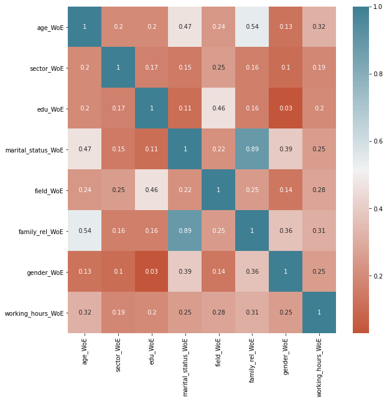

```python
plt.figure(figsize=(10, 10))
correlation = X.corr()
sns.heatmap(X.corr(), annot=True, cmap=sns.diverging_palette(20, 220, n=200))
```

2 biến marial status và family_rel có correlation, và biến marital status sẽ bị loại do có IV thấp hơn , tập X Y lúc này sẽ bao gồm những biến sau

```python
X = df_logistic[['age_WoE',
       'sector_WoE', 'edu_WoE', 'field_WoE',
       'family_rel_WoE', 'gender_WoE', 'working_hours_WoE']]
Y = df_logistic["high_income"]
X.head()
```

|  | age_WoE | sector_WoE | edu_WoE | field_WoE | family_rel_WoE | gender_WoE | working_hours_WoE |
| --- | --- | --- | --- | --- | --- | --- | --- |
| 0 | -0.490029 | -0.163529 | -0.803894 | 0.713645 | 1.015318 | -0.328119 | 0.168462 |
| 1 | -0.739096 | -0.228096 | -0.803894 | -1.084280 | -0.941801 | -0.328119 | 1.461364 |
| 2 | -0.490029 | 0.125171 | 0.513642 | 1.555142 | 1.015318 | -0.328119 | 0.168462 |
| 3 | -0.656024 | 0.125171 | 1.774019 | 1.555142 | -0.941801 | -0.328119 | 0.168462 |
| 4 | 0.589611 | 0.125171 | -0.803894 | -0.943671 | -1.048674 | 0.948017 | 0.168462 |

```python
X.isnull().values.sum()
```

```
0
```

```python
X.isnull().any()
```

```
age_WoE              False
sector_WoE           False
edu_WoE              False
field_WoE            False
family_rel_WoE       False
gender_WoE           False
working_hours_WoE    False
dtype: bool
```

# Phân tích đa biến backward selection

```python
 #If the absolute p-value is smaller than 0.05, it means that the feature affects high_income in a statistically significant way => all variables are significant
```

Lấy ngẫu nhiên 20% số lượng KH trên tập train.xlsx để làm dữ liệu validation.

```python
X_train, X_test, y_train, y_test = train_test_split(X, Y, test_size=0.2, random_state=18)
```

```python
import os

import statsmodels.api as sm
# from mlxtend.feature_selection import SequentialFeatureSelector as SFS
# from sklearn.linear_model import LogisticRegression

import warnings
warnings.filterwarnings("ignore")
```

1. Choose a significance level (e.g. SL = 0.05 with a 95% confidence).
2. Fit a full model including all the features.
3. Consider the feature with the highest p-value. If the p-value > significance level then go to Step 4, otherwise terminate the process.
4. Remove the feature which is under consideration.
5. Fit a model without this feature. Repeat the entire process from Step 3.

```python
def backward_elimination(data, target,significance_level = 0.05):
    features = data.columns.tolist()
    while(len(features)>0):
        features_with_constant = sm.add_constant(data[features])
        p_values = sm.Logit(target, features_with_constant).fit().pvalues[1:]

        max_p_value = p_values.max()
        if(max_p_value >= significance_level):
            excluded_feature = p_values.idxmax()
            features.remove(excluded_feature)
#             print('Add  {:30} with p-value {:.6}'.format(best_feature, max_p_value))
        else:
            break
    features_with_constant_sum = sm.add_constant(data[features])
    logit = sm.Logit(target, features_with_constant_sum).fit()
    result_summary= logit.summary()
    return logit, result_summary, features
#     return  features
```

```python
backward_elimination(X_train, y_train)
```

```
Optimization terminated successfully.
         Current function value: 0.351861
         Iterations 8
Optimization terminated successfully.
         Current function value: 0.351861
         Iterations 8
```

```
(<statsmodels.discrete.discrete_model.BinaryResultsWrapper at 0x22bc9afe1c0>,
 <class 'statsmodels.iolib.summary.Summary'>
 """
                            Logit Regression Results
 ==============================================================================
 Dep. Variable:            high_income   No. Observations:                26048
 Model:                          Logit   Df Residuals:                    26040
 Method:                           MLE   Df Model:                            7
 Date:                Sun, 16 Oct 2022   Pseudo R-squ.:                  0.3629
 Time:                        17:15:27   Log-Likelihood:                -9165.3
 converged:                       True   LL-Null:                       -14386.
 Covariance Type:            nonrobust   LLR p-value:                     0.000
 =====================================================================================
                         coef    std err          z      P>|z|      [0.025      0.975]
 -------------------------------------------------------------------------------------
 const                -1.2802      0.022    -58.497      0.000      -1.323      -1.237
 age_WoE              -0.6485      0.031    -20.897      0.000      -0.709      -0.588
 sector_WoE           -0.0914      0.046     -1.987      0.047      -0.182      -0.001
 edu_WoE              -0.7534      0.024    -31.535      0.000      -0.800      -0.707
 field_WoE            -0.4949      0.025    -19.631      0.000      -0.544      -0.445
 family_rel_WoE       -0.9236      0.022    -42.472      0.000      -0.966      -0.881
 gender_WoE           -0.1002      0.040     -2.477      0.013      -0.180      -0.021
 working_hours_WoE    -0.4839      0.030    -16.261      0.000      -0.542      -0.426
 =====================================================================================
 """,
 ['age_WoE',
  'sector_WoE',
  'edu_WoE',
  'field_WoE',
  'family_rel_WoE',
  'gender_WoE',
  'working_hours_WoE'])
```

```python
x_train = X_train[['age_WoE',
  'sector_WoE',
  'edu_WoE',
  'field_WoE',
  'family_rel_WoE',
  'gender_WoE',
  'working_hours_WoE']]
```

```python
x_test = X_test[['age_WoE',
  'sector_WoE',
  'edu_WoE',
  'field_WoE',
  'family_rel_WoE',
  'gender_WoE',
  'working_hours_WoE']]
```

Không có biến nào bị loại, 7 biến này sẽ được sử dụng để xây dựng Logistic, Random Forest theo yêu cầu đề bài

# LOGISTIC REGRESSION

```python
from sklearn.linear_model import LogisticRegression
from sklearn.ensemble import RandomForestClassifier
from sklearn.neighbors import KNeighborsClassifier
from sklearn.tree import DecisionTreeClassifier
from sklearn.preprocessing import OneHotEncoder
from sklearn.metrics import accuracy_score, confusion_matrix
from sklearn.metrics import roc_curve, roc_auc_score, auc
from scipy import stats
import matplotlib.pyplot as plt
import sklearn.metrics as metrics
```

```python
#instantiate model and train
logit_model = LogisticRegression()
logit_model.fit(x_train, y_train)
# make predictions for test set
y_train_predict = logit_model.predict(x_train)
y_pred = logit_model.predict(x_test)
accuracy_train_logit = accuracy_score(y_train, y_train_predict)
accuracy_test_logit = accuracy_score(y_test, y_pred)

y_pred_prob_train = logit_model.predict_proba(x_train)[:, 1]
y_pred_prob_test = logit_model.predict_proba(x_test)[:, 1]

auc_train_rd = metrics.roc_auc_score(y_train, y_pred_prob_train)
auc_test_rd = metrics.roc_auc_score(y_test, y_pred_prob_test)

Precision_logit = metrics.precision_score(y_test, y_pred)* 100.0
Recall_logit = metrics.recall_score(y_test, y_pred)* 100.0
F1_logit = 2 * (Precision_logit * Recall_logit) / (Precision_logit + Recall_logit)

gini_train_logit = 2*auc_train_rd - 1
gini_test_logit = 2*auc_test_rd - 1
print("Logistic Regression")
print("Gini Train: %.2f%%" % (gini_train_logit  * 100.0))
print("Gini Test: %.2f%%" % (gini_test_logit * 100.0))
print("Accuracy Train: %.2f%%" % (accuracy_train_logit  * 100.0))
print("Accuracy Test: %.2f%%" % (accuracy_test_logit * 100.0))
```

```
Logistic Regression
Gini Train: 77.06%
Gini Test: 77.55%
Accuracy Train: 83.51%
Accuracy Test: 83.48%
```

Vẽ đường ROC (Receiver Operating Curve) & tính toán chỉ số AUC (Area Under the Curve)

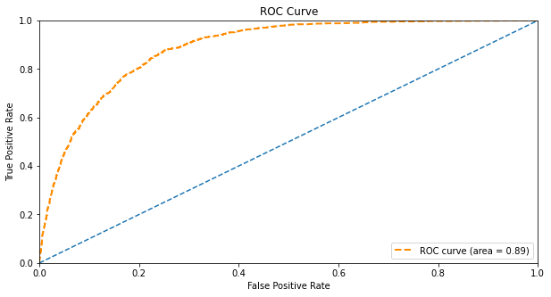

```python
from sklearn.metrics import roc_curve, auc

y_pred_prob_test = logit_model.predict_proba(x_test)[:, 1]
fpr, tpr, thres = roc_curve(y_test, y_pred_prob_test)
roc_auc = auc(fpr, tpr)

def _plot_roc_curve(fpr, tpr, thres, auc):
    plt.figure(figsize = (10, 5))
    plt.plot(fpr, tpr, 'b-', color='darkorange', lw=2, linestyle='--', label='ROC curve (area = %0.2f)'%auc)
    plt.plot([0, 1], [0, 1], '--')
    plt.axis([0, 1, 0, 1])
    plt.xlabel('False Positive Rate')
    plt.ylabel('True Positive Rate')
    plt.legend(loc='lower right')
    plt.title('ROC Curve')

_plot_roc_curve(fpr, tpr, thres, roc_auc)
```

AUC của logistic regression trên tập validation là 0.89

```python
#Xây dựng confusion matrix với cutoff point = 0.5 (xác suất KH có thu nhập cao - high_income = yes)
```

```python
def calculate_confusion_matrix (y_true, y_prob, threshold):
  y_pred = np.where(y_prob >= threshold, 1, 0)
  fp = np.sum((y_pred == 1) & (y_true == 0))
  tp = np.sum((y_pred == 1) & (y_true == 1))

  fn = np.sum((y_pred == 0) & (y_true == 1))
  tn = np.sum((y_pred == 0) & (y_true == 0))
  return tp, fp, fn, tn
```

```python
calculate_confusion_matrix (y_test, y_pred_prob_test, 0.5)
```

```
(840, 354, 722, 4597)
```

Với cut off point = 0.5 confusion matrix được tính toán như sau

```python
#Precision = TP/ TP+ FP hay
840 / (840+354)
```

```
0.7035175879396985
```

```python
#Recall = TP/ TP+ FN hay
840 / (840+722)
```

```
0.5377720870678617
```

```python
#F1_Score = 2 * (precision * recall) / (precision + recall) hay
2 * (0.7035175879396985 * 0.5377720870678617) / (0.7035175879396985 + 0.5377720870678617)
```

```
0.6095791001451379
```

```python
#Dựa vào confusion matrix, tính toán: accuracy, precision, recall, F1-score, FPR (false positive rate)
# gói gọn trong hàm ta được
```

```python
import numpy as np


def roc_curve(y_true, y_prob, threshold):

        fpr = []
        tpr = []

        y_pred = np.where(y_prob >= threshold, 1, 0)

        fp = np.sum((y_pred == 1) & (y_true == 0))
        tp = np.sum((y_pred == 1) & (y_true == 1))

        fn = np.sum((y_pred == 0) & (y_true == 1))
        tn = np.sum((y_pred == 0) & (y_true == 0))

        fpr.append(fp / (fp + tn))
        tpr.append(tp / (tp + fn))
        precision = tp / (tp + fp)
        recall = tp / (tp + fn)
        F1_Score = 2 * (precision * recall) / (precision + recall)
        Accuracy = (tp+tn) / (tp+tn+fp +fn)

        return [fpr, precision,recall,F1_Score,Accuracy]
```

```python
roc_curve(y_test, y_pred_prob_test, 0.5)
```

```
[[0.07150070692789336],
 0.7035175879396985,
 0.5377720870678617,
 0.6095791001451379,
 0.8347919545524336]
```

- tỷ lệ false positive rate là 7.1%,
- precision 70.35% : đây tỷ lệ giữa những người thật sự có thu nhập cao so với tất cả các khách hàng được dự đoán là có thu nhập cao
- recall 53.77% :trong những người có thu nhập cao trong tập dữ liệu, 53.77% được dự đoán đúng bởi mô hình của chúng ta
- F1 hữu dụng khi cần 1 sự cân bằng giữa precision và recall tương đương 61%
- accuracy tương đương tỷ lệ dự đoán đúng là 83.48%

```python
#Lấy ra top 5 biến ảnh hưởng nhiều nhất tới biến output (theo logistic regression)
```

```python
feature_names = ['age_WoE',
  'sector_WoE',
  'edu_WoE',
  'field_WoE',
  'family_rel_WoE',
  'gender_WoE',
  'working_hours_WoE']
```

```python
weights = logit_model.coef_
abs_weights = np.abs(weights)

print(abs_weights)
```

```
[[0.64787445 0.09156783 0.75303519 0.49472259 0.92309931 0.10033153
  0.48347826]]
```

Theo yêu cầu của đề bài, Lấy ra top 5 biến ảnh hưởng nhiều nhất tới biến output,theo thứ tự độ lớn của coefficient, sẽ là biến family rel, edu, age, field và working hours

# Feature Scaling, One- Hot Encoder

scaling hay normalization là cách biến đổi dữ liệu biến liên tục về chuẩn hóa với mean - 0 (zero); standard deviation - 1 one hot encoder là cách biến đổi biển phân loại, tạo ra n cột mới với giá trị binary 0 hoặc 1 tùy vào n giá trị được phân loại trong biến woe là cách biến đổi cho logistic regression, thay vì dùng woe, bài làm sẽ dùng standard scaler và one hot encoder để biến đổi dữ liệu dùng cho random forest

```python
df1.info()
```

```
<class 'pandas.core.frame.DataFrame'>
RangeIndex: 32561 entries, 0 to 32560
Data columns (total 12 columns):
 #   Column           Non-Null Count  Dtype
---  ------           --------------  -----
 0   id               32561 non-null  int64
 1   age              32561 non-null  int64
 2   sector           32561 non-null  object
 3   edu              32561 non-null  object
 4   marital_status   32561 non-null  object
 5   field            32561 non-null  object
 6   family_rel       32561 non-null  object
 7   gender           32561 non-null  object
 8   investment_gain  32561 non-null  int64
 9   investment_loss  32561 non-null  int64
 10  working_hours    32561 non-null  int64
 11  high_income      32561 non-null  object
dtypes: int64(5), object(7)
memory usage: 3.0+ MB
```

```python
df1['high_income'] = np.where(df1['high_income'] == 'no', 0, 1)
```

```python
# Lấy list names của các biến phân loại và biến liên tục.
cat_names = list(df1.select_dtypes('object').columns)
num_names = list(df1.select_dtypes(['float', 'int64']).columns)
```

```python
cat_names
```

```
['sector', 'edu', 'marital_status', 'field', 'family_rel', 'gender']
```

```python
num_names
```

```
['id', 'age', 'investment_gain', 'investment_loss', 'working_hours']
```

```python
from sklearn.preprocessing import LabelEncoder, OneHotEncoder, StandardScaler
```

['age_WoE', 'sector_WoE', 'edu_WoE', 'field_WoE', 'family_rel_WoE', 'gender_WoE', 'working_hours_WoE'] là các biến được chọn sau phân tích đơn biến dựa trên IV phía trên

```python
one_hot_encoded_data = pd.get_dummies(df1, columns = ['sector', 'edu', 'field', 'family_rel', 'gender'])
```

```python
# các biến phân loại hiện tại bao gồm
```

```python
one_hot_encoded_data.columns
```

```
Index(['id', 'age', 'marital_status', 'investment_gain', 'investment_loss',
       'working_hours', 'high_income', 'sector_ ?', 'sector_ Federal-gov',
       'sector_ Local-gov', 'sector_ Never-worked', 'sector_ Private',
       'sector_ Self-emp-inc', 'sector_ Self-emp-not-inc', 'sector_ State-gov',
       'sector_ Without-pay', 'edu_ 10th', 'edu_ 11th', 'edu_ 12th',
       'edu_ 1st-4th', 'edu_ 5th-6th', 'edu_ 7th-8th', 'edu_ 9th',
       'edu_ Assoc-acdm', 'edu_ Assoc-voc', 'edu_ Bachelors', 'edu_ Doctorate',
       'edu_ HS-grad', 'edu_ Masters', 'edu_ Preschool', 'edu_ Prof-school',
       'edu_ Some-college', 'field_ ?', 'field_ Adm-clerical',
       'field_ Armed-Forces', 'field_ Craft-repair', 'field_ Exec-managerial',
       'field_ Farming-fishing', 'field_ Handlers-cleaners',
       'field_ Machine-op-inspct', 'field_ Other-service',
       'field_ Priv-house-serv', 'field_ Prof-specialty',
       'field_ Protective-serv', 'field_ Sales', 'field_ Tech-support',
       'field_ Transport-moving', 'family_rel_ Husband',
       'family_rel_ Not-in-family', 'family_rel_ Other-relative',
       'family_rel_ Own-child', 'family_rel_ Unmarried', 'family_rel_ Wife',
       'gender_ Female', 'gender_ Male'],
      dtype='object')
```

```python
one_hot_encoded_data = one_hot_encoded_data[['high_income', 'sector_ ?', 'sector_ Federal-gov',
       'sector_ Local-gov', 'sector_ Never-worked', 'sector_ Private',
       'sector_ Self-emp-inc', 'sector_ Self-emp-not-inc', 'sector_ State-gov',
       'sector_ Without-pay', 'edu_ 10th', 'edu_ 11th', 'edu_ 12th',
       'edu_ 1st-4th', 'edu_ 5th-6th', 'edu_ 7th-8th', 'edu_ 9th',
       'edu_ Assoc-acdm', 'edu_ Assoc-voc', 'edu_ Bachelors', 'edu_ Doctorate',
       'edu_ HS-grad', 'edu_ Masters', 'edu_ Preschool', 'edu_ Prof-school',
       'edu_ Some-college', 'field_ ?', 'field_ Adm-clerical',
       'field_ Armed-Forces', 'field_ Craft-repair', 'field_ Exec-managerial',
       'field_ Farming-fishing', 'field_ Handlers-cleaners',
       'field_ Machine-op-inspct', 'field_ Other-service',
       'field_ Priv-house-serv', 'field_ Prof-specialty',
       'field_ Protective-serv', 'field_ Sales', 'field_ Tech-support',
       'field_ Transport-moving', 'family_rel_ Husband',
       'family_rel_ Not-in-family', 'family_rel_ Other-relative',
       'family_rel_ Own-child', 'family_rel_ Unmarried', 'family_rel_ Wife',
       'gender_ Female', 'gender_ Male']]
```

```python
sc = StandardScaler()
```

```python
# transform các biến liên tục
```

```python
# Scaling only continuous columns
cols_to_scale = ['age',  'working_hours']
sc_X_train = sc.fit_transform(df1[['age',  'working_hours']])
# Converting from array to dataframe and naming the respective features/columns
sc_X_train = pd.DataFrame(data=sc_X_train, columns=cols_to_scale)
sc_X_train.shape
sc_X_train.head()
```

|  | age | working_hours |
| --- | --- | --- |
| 0 | 0.030671 | -0.035429 |
| 1 | 0.837109 | -2.222153 |
| 2 | -0.042642 | -0.035429 |
| 3 | 1.057047 | -0.035429 |
| 4 | -0.775768 | -0.035429 |

```python
df1 = pd.concat([sc_X_train, one_hot_encoded_data],
          axis=1)
```

```python
#gộp biến liên tục + biến phân loại
```

```python
df1.columns
```

```
Index(['age', 'working_hours', 'high_income', 'sector_ ?',
       'sector_ Federal-gov', 'sector_ Local-gov', 'sector_ Never-worked',
       'sector_ Private', 'sector_ Self-emp-inc', 'sector_ Self-emp-not-inc',
       'sector_ State-gov', 'sector_ Without-pay', 'edu_ 10th', 'edu_ 11th',
       'edu_ 12th', 'edu_ 1st-4th', 'edu_ 5th-6th', 'edu_ 7th-8th', 'edu_ 9th',
       'edu_ Assoc-acdm', 'edu_ Assoc-voc', 'edu_ Bachelors', 'edu_ Doctorate',
       'edu_ HS-grad', 'edu_ Masters', 'edu_ Preschool', 'edu_ Prof-school',
       'edu_ Some-college', 'field_ ?', 'field_ Adm-clerical',
       'field_ Armed-Forces', 'field_ Craft-repair', 'field_ Exec-managerial',
       'field_ Farming-fishing', 'field_ Handlers-cleaners',
       'field_ Machine-op-inspct', 'field_ Other-service',
       'field_ Priv-house-serv', 'field_ Prof-specialty',
       'field_ Protective-serv', 'field_ Sales', 'field_ Tech-support',
       'field_ Transport-moving', 'family_rel_ Husband',
       'family_rel_ Not-in-family', 'family_rel_ Other-relative',
       'family_rel_ Own-child', 'family_rel_ Unmarried', 'family_rel_ Wife',
       'gender_ Female', 'gender_ Male'],
      dtype='object')
```

```python
df1.shape
```

```
(32561, 51)
```

```python
X = df1.drop(labels = ["high_income"],axis = 1)
Y = df1["high_income"]
X.head()
```

|  | age | working_hours | sector_ ? | sector_ Federal-gov | sector_ Local-gov | sector_ Never-worked | sector_ Private | sector_ Self-emp-inc | sector_ Self-emp-not-inc | sector_ State-gov | ... | field_ Tech-support | field_ Transport-moving | family_rel_ Husband | family_rel_ Not-in-family | family_rel_ Other-relative | family_rel_ Own-child | family_rel_ Unmarried | family_rel_ Wife | gender_ Female | gender_ Male |
| --- | --- | --- | --- | --- | --- | --- | --- | --- | --- | --- | --- | --- | --- | --- | --- | --- | --- | --- | --- | --- | --- |
| 0 | 0.030671 | -0.035429 | 0 | 0 | 0 | 0 | 0 | 0 | 0 | 1 | ... | 0 | 0 | 0 | 1 | 0 | 0 | 0 | 0 | 0 | 1 |
| 1 | 0.837109 | -2.222153 | 0 | 0 | 0 | 0 | 0 | 0 | 1 | 0 | ... | 0 | 0 | 1 | 0 | 0 | 0 | 0 | 0 | 0 | 1 |
| 2 | -0.042642 | -0.035429 | 0 | 0 | 0 | 0 | 1 | 0 | 0 | 0 | ... | 0 | 0 | 0 | 1 | 0 | 0 | 0 | 0 | 0 | 1 |
| 3 | 1.057047 | -0.035429 | 0 | 0 | 0 | 0 | 1 | 0 | 0 | 0 | ... | 0 | 0 | 1 | 0 | 0 | 0 | 0 | 0 | 0 | 1 |
| 4 | -0.775768 | -0.035429 | 0 | 0 | 0 | 0 | 1 | 0 | 0 | 0 | ... | 0 | 0 | 0 | 0 | 0 | 0 | 0 | 1 | 1 | 0 |

5 rows × 50 columns

```python
#Lấy ngẫu nhiên 20% số lượng KH trên tập train.xlsx để làm dữ liệu validation.
```

```python
X_train, X_test, Y_train, Y_test = train_test_split(X, Y, test_size=0.2, random_state=30)
```

# Random Forest

```python
X_train.shape
```

```
(26048, 50)
```

```python
# RandomForestClassifier
from sklearn.ensemble import RandomForestClassifier

random_forest = RandomForestClassifier().fit(X_train, Y_train)
y_train_predict = random_forest.predict(X_train)
y_pred = random_forest.predict(X_test)

accuracy_train_forest = accuracy_score(Y_train, y_train_predict)
accuracy_test_forest = accuracy_score(Y_test, y_pred)


y_pred_prob_train = random_forest.predict_proba(X_train)[:, 1]
y_pred_prob_test = random_forest.predict_proba(X_test)[:, 1]

auc_train_rd = metrics.roc_auc_score(Y_train, y_pred_prob_train)
auc_test_rd = metrics.roc_auc_score(Y_test, y_pred_prob_test)

gini_train_rd = 2*auc_train_rd - 1
gini_test_rd = 2*auc_test_rd - 1
Precision_rd = metrics.precision_score(Y_test, y_pred)* 100.0
Recall_rd = metrics.recall_score(Y_test, y_pred)* 100.0

F1_rd = 2 * (Precision_rd * Recall_rd) / (Precision_rd + Recall_rd)
print(" RandomForest ")
print("Gini Train: %.2f%%" % (gini_train_rd  * 100.0))
print("Gini Test: %.2f%%" % (gini_test_rd * 100.0))

print("Accuracy: %.2f%%" % (accuracy_train_forest * 100.0))
print("Accuracy: %.2f%%" % (accuracy_test_forest * 100.0))
```

```
 RandomForest
Gini Train: 98.71%
Gini Test: 69.75%
Accuracy: 96.23%
Accuracy: 81.47%
```

```python
#Vẽ đường ROC (Receiver Operating Curve) & tính toán chỉ số AUC (Area Under the Curve)
```

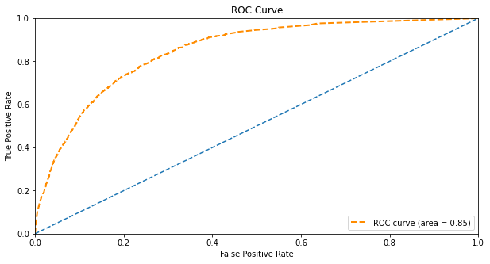

```python
from sklearn.metrics import roc_curve, auc

y_pred_prob_test = random_forest.predict_proba(X_test)[:, 1]
fpr, tpr, thres = roc_curve(Y_test, y_pred_prob_test)
roc_auc = auc(fpr, tpr)

def _plot_roc_curve(fpr, tpr, thres, auc):
    plt.figure(figsize = (10, 5))
    plt.plot(fpr, tpr, 'b-', color='darkorange', lw=2, linestyle='--', label='ROC curve (area = %0.2f)'%auc)
    plt.plot([0, 1], [0, 1], '--')
    plt.axis([0, 1, 0, 1])
    plt.xlabel('False Positive Rate')
    plt.ylabel('True Positive Rate')
    plt.legend(loc='lower right')
    plt.title('ROC Curve')

_plot_roc_curve(fpr, tpr, thres, roc_auc)
```

AUC của random forest trên tập validation là 0.85

```python
#Xây dựng confusion matrix với cutoff point = 0.5 (xác suất KH có thu nhập cao - high_income = yes)
```

```python
calculate_confusion_matrix (Y_test, y_pred_prob_test, 0.5)
```

```
(847, 512, 696, 4458)
```

- True Positive (TP): 847 kh ta đoán là thu nhập cao đúng là thu nhập cao
- False Positive (FP): 512 kh ta đoán là thu nhập cao thật ra thu nhập thấp.
- False Negative (FN): 696 kh ta đoán là thu nhập thấp thật ra thu nhập cao
- True Negative (TN): 4458 kh ta đoán là thu nhập thấp đúng là thu nhập thấp.

```python
fpr.append(fp / (fp + tn))
precision = tp / (tp + fp)
recall = tp / (tp + fn)
F1_Score = 2 * (precision * recall) / (precision + recall)
Accuracy = (tp+tn) / (tp+tn+fp +fn)
```

```python
 #FPR
512 / (512+4458)
```

```
0.10301810865191147
```

```python
# Precision
847 / (847 + 512)
```

```
0.623252391464312
```

```python
# Recall
847 / (847 + 696)
```

```
0.5489306545690213
```

```python
# F1
2 * (0.623252391464312 * 0.5489306545690213) / (0.623252391464312 + 0.5489306545690213)
```

```
0.5837353549276361
```

```python
#Accuracy =
(847+4458) / (847 + 512 + 696 + 4458)
```

```
0.8145247965607247
```

```python
# get importance
importance = random_forest.feature_importances_
```

```python
feature_names = X_train.columns
```

```python
feature_importances = pd.DataFrame(random_forest.feature_importances_,  index =feature_names,  columns=['importance']).sort_values('importance', ascending=False)
feature_importances.head()
```

|  | importance |
| --- | --- |
| age | 0.326932 |
| working_hours | 0.154868 |
| family_rel_ Husband | 0.091638 |
| field_ Prof-specialty | 0.028618 |
| family_rel_ Wife | 0.028303 |

Lấy ra top 5 biến ảnh hưởng nhiều nhất tới biến output: Theo kết quả từ random forest: 5 biến quan trọng nhất là age, working hours, family_rel_husband, field_prof-specialty, family_rel_wife

# Đánh giá chất lượng mô hình trên tập validation (đã được chọn ở trên), so sánh kết quả giữa 2 thuật toán Logistic, Random Forest

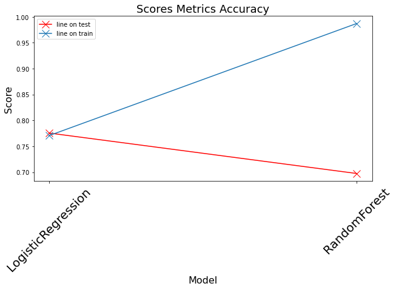

```python
# Visualize accuracy train và validation
plt.figure(figsize=(10, 5))
all_score_train = [ gini_train_logit,gini_train_rd]
all_score_val = [gini_test_logit,gini_test_rd]
model_names = ['LogisticRegression','RandomForest']

plt.plot(np.arange(len(all_score_val))+1, all_score_val, marker='x', markersize=12,color='red')
plt.plot(np.arange(len(all_score_train))+1, all_score_train, marker='x', markersize=12)

plt.legend(['line on test', 'line on train'])

plt.xlabel('Model', fontsize=16)
plt.ylabel('Score', fontsize=16)

plt.xticks(np.arange(len(model_names))+1, model_names, rotation=45, fontsize=20)
plt.title("Scores Metrics Accuracy", fontsize=18)
```

```python
models = pd.DataFrame({
    'Model': ['Logistic Regression','RandomForest'],
       'GINI train': [ gini_train_logit,gini_train_rd]  ,
    'GINI test': [gini_test_logit,gini_test_rd] ,
       'Precision': [ Precision_logit,Precision_rd],
    'Recall': [ Recall_logit,Recall_rd],
    'Accuracy': [accuracy_test_logit, accuracy_test_forest],
    'F1': [F1_logit, F1_rd]
})
models['% Gini difference'] = (models['GINI train'] - models['GINI test']) * 100.0
models.sort_values(by='GINI test', ascending=False)
```

|  | Model | GINI train | GINI test | Precision | Recall | Accuracy | F1 | % Gini difference |
| --- | --- | --- | --- | --- | --- | --- | --- | --- |
| 0 | Logistic Regression | 0.770633 | 0.775550 | 70.351759 | 53.777209 | 0.834792 | 60.957910 | -0.491681 |
| 1 | RandomForest | 0.987056 | 0.697469 | 62.426036 | 54.698639 | 0.814678 | 58.307427 | 28.958695 |

Đánh giá chất lượng mô hình trên tập validation (đã được chọn ở trên), so sánh kết quả giữa 2 thuật toán Logistic, Random Forest:

- Mô hình Random Forest tuy có Gini cao ở tập huấn luyện nhưng ở tập kiểm thử gini có sự chênh lệch rất lớn => không tổng quát và overfit
- Mô hình Logistic Regression có Gini ở mức tối ~78%, có chênh lệch giữa tập train và test < 1 %
- Precision của logistic tốt hơn random forest, dự đoán high income customers mà mô hình logistic đưa ra chính xác lên tới 70%
- Recall 2 mô hình tương đương nhau ở mức 54%
- Độ chính xác accuracy của mô hình logistic nhỉnh hơn, F1 của mô hình logistic regression cũng nhỉnh hơn = > mô hình được lựa chọn là logistic regression

# Dự đoán trên tập test

```python
test = pd.read_excel('C:/Users/Admin/Downloads/test.xlsx')
```

```python
for col_name in ['age','sector',
  'edu',
  'field',
  'family_rel','gender',
  'working_hours']:
    test[col_name + '_WoE'] = test[col_name].map(WoE_features[col_name]['summary']['WoE'])
test.head()
```

|  | id | age | sector | edu | marital_status | field | family_rel | gender | investment_gain | investment_loss | working_hours | high_income_predict | age_WoE | sector_WoE | edu_WoE | field_WoE | family_rel_WoE | gender_WoE | working_hours_WoE |
| --- | --- | --- | --- | --- | --- | --- | --- | --- | --- | --- | --- | --- | --- | --- | --- | --- | --- | --- | --- |
| 0 | 32562 | 25 | Private | 11th | Never-married | Machine-op-inspct | Own-child | Male | 0 | 0 | 40 | 0.0 | 1.835464 | 0.125171 | 1.774019 | 0.798806 | 3.164454 | -0.328119 | 0.168462 |
| 1 | 32563 | 38 | Private | HS-grad | Married-civ-spouse | Farming-fishing | Husband | Male | 0 | 0 | 50 | 0.0 | -0.490029 | 0.125171 | 0.513642 | 0.885607 | -0.941801 | -0.328119 | -0.930847 |
| 2 | 32564 | 28 | Local-gov | Assoc-acdm | Married-civ-spouse | Protective-serv | Husband | Male | 0 | 0 | 40 | 0.0 | 0.589611 | -0.276024 | -0.040867 | -0.417885 | -0.941801 | -0.328119 | 0.168462 |
| 3 | 32565 | 44 | Private | Some-college | Married-civ-spouse | Machine-op-inspct | Husband | Male | 7688 | 0 | 40 | 0.0 | -0.614660 | 0.125171 | 0.300241 | 0.798806 | -0.941801 | -0.328119 | 0.168462 |
| 4 | 32566 | 18 | ? | Some-college | Never-married | ? | Own-child | Female | 0 | 0 | 30 | 0.0 | 4.224199 | 1.004976 | 0.300241 | 1.009222 | 3.164454 | 0.948017 | 1.058554 |

```python
test_data = test[['age_WoE',
  'sector_WoE',
  'edu_WoE',
  'field_WoE',
  'family_rel_WoE',
  'gender_WoE',
  'working_hours_WoE']]
```

```python
test_predict  = logit_model.predict_proba(test_data)[:, 1]
```

```python
test_data = test_data.reset_index()
```

```python
df_predict = pd.concat([pd.DataFrame(test_data), pd.DataFrame(test_predict)], axis = 1)
```

```python
df_predict.columns.values[-1:] = ["high_income_predict_probability" ]
```

```python
df_predict.shape
```

```
(16281, 9)
```

```python
test_raw = test[['id', 'age', 'sector', 'edu', 'marital_status', 'field', 'family_rel',
       'gender', 'investment_gain', 'investment_loss', 'working_hours']]
```

```python
test_raw = test_raw.reset_index()
```

```python
df_predict = pd.concat([df_predict, test_raw], axis = 1)
```

```python
df_predict.to_excel('C:\\Users\\Admin\\Downloads\\Train_Predict_Probability.xlsx',index = False)
```